### SSHI sockeye exploratory analyses (stage 1)

#### by B. Connors

##### revised by A. Teffer

2021-05-20

Quick exploratory analyses to derive Fraser sockeye survival indices. All code and associated data can be found on Github [here](https://github.com/brendanmichaelconnors/SSHI-sockeye).

Fraser brood table provided to A. Teffer by PSC, recent missing estimates of spawners in PSC brood table were added from file provided to A. Teffer by DFO (M. Hawkshaw).

Updated data from Steve Latham at PSC: (productiondata(by_stock)VERYprel-20mailout(Oct02_20).xlsx). Updated return data from Tracy Cone at DFO:(Sockeye all from 1950.xlsx) -> all integrated into “fraser_brood_table_210519.txt” in data folder by AKT

To (re)generate the SST data you need to run the “sst_anomalies.R” file that is commented out below and make sure the ersst package is installed (see [here](https://github.com/michaelmalick/r-ersst)).

To do:

- predict 5 year old recruits for 2014 brood year for all stocks based on stock-specific average proportion of 5 year old recruits, right now 5 year olds from the 2014 broodyear (that will return this summer) are simply assumed to be zero.
- consider adding central coast stocks (Atnarko and Owikeno) to analyses

```r
## load required packages and functions
library(ersst)
library(plyr)
library(tidyverse)
library(viridis)
source("functions.R")
# source("sst_anomalies.R")
```

```r
## load Fraser sockeye brood table
raw_brood_table <- read.delim("data/fraser_brood_table_210519.txt")
raw_brood_table$total_effective_female_spawner <- as.factor(raw_brood_table$total_effective_female_spawner)
#str(raw_brood_table)

## clean up brood table, add a few new columns
brood_table <- subset(raw_brood_table, BY < 2016)
brood_table <- subset(brood_table, BY > 1949)
brood_table <- subset(brood_table, stock_name != "Cultus")
brood_table$efs <-as.numeric(levels(brood_table$total_effective_female_spawner)
                    )[brood_table$total_effective_female_spawner]

brood_table$efs_lag1 <-lag(brood_table$efs,1)
brood_table$efs_lag2 <-lag(brood_table$efs,2)
brood_table$efs_lag3 <-lag(brood_table$efs,3)
brood_table$age.51 <- 0
brood_table$lnRS <-log(brood_table$recruits_no_jacks/brood_table$efs)
brood_table <- brood_table[!is.na(brood_table$lnRS),]
brood_table <- brood_table[brood_table$lnRS != "-Inf",]
brood_table<-brood_table[!is.na(brood_table$Stock.ID),]

## add columns with ocean entry age proportions
brood_table$ocean_0 <- (brood_table$age.21+
                          brood_table$age.31+
                          brood_table$age.41+
                          brood_table$age.51)/brood_table$total_recruits

brood_table$ocean_1 <- (brood_table$age.32+
                          brood_table$age.42+
                          brood_table$age.52+
                          brood_table$age.62)/brood_table$total_recruits

brood_table$ocean_2 <- (brood_table$age.43+
                          brood_table$age.53+
                          brood_table$age.63)/brood_table$total_recruits
head(brood_table)
```

```
##   stock_name Stock.ID   BY total_adult_spawner
## 3   E.Stuart        1 1950               59443
## 4   E.Stuart        1 1951               61070
## 5   E.Stuart        1 1952               40652
## 6   E.Stuart        1 1953              154586
## 7   E.Stuart        1 1954               38482
## 8   E.Stuart        1 1955                2290
##   total_effective_female_spawner juv_type juvenile_estimate age.21 age.31
## 3                     25657.9205       NA                NA      0      0
## 4                     29801.2067       NA                NA      0      0
## 5                     19750.7686       NA                NA      0      0
## 6                     78293.6337       NA                NA      0      0
## 7                     19757.0752       NA                NA      0      0
## 8                      1448.0714       NA                NA      0      0
##   age.32 age.41 age.42 age.43 age.51 age.52 age.53 age.62 age.63
```

[output cut: 20 more lines]

```r
## derive ocean entry year SST anomaly indices
##  weighted average across year and stock specific age at ocean entry
raw.clim <- read.csv(file="data/sst_yr_1_stock_anomalies.csv",header=TRUE)
early.sst <- clim.wgt.avg(brood.table = brood_table,
                          env.data = raw.clim,
                          env.covar = "sst_anomaly",
                          type = "first_year",
                          out.covar = "early_sst")
head(early.sst)
```

```
##     BY Stock.ID   early_sst
## 1 1950        1 -0.72297764
## 2 1951        1 -0.17913710
## 3 1952        1 -0.73062141
## 4 1953        1 -1.06181738
## 5 1954        1 -0.08162097
## 6 1955        1  0.39519085
```

```r
## derive pink salmon competitor indices
##  empirical  through 2015, extrapolated based on last four years of data
##  for odd and even lines thereafter
raw.comp <- read.csv(file="data/pink_abundance_2017_12_08.csv",header=TRUE)

extrap_pinks <- matrix(NA,4,16,dimnames = list(seq(1:4),colnames(raw.comp)))
extrap_pinks[1:4,1] <- c(2016,2017,2018,2019)
extrap_pinks[1:4,16] <- c(median(raw.comp$Total[c(57,59,61,63)]),
                          median(raw.comp$Total[c(58,60,62,64)]),
                          median(raw.comp$Total[c(57,59,61,63)]),
                          median(raw.comp$Total[c(58,60,62,64)]))

raw.comp <- rbind(raw.comp,extrap_pinks)

np.pink <- pink.wgt.avg(brood.table = brood_table,
                        pink.data = raw.comp,
                        pink.covar = "Total",
                        type = "second_year",
                        out.covar = "np_pinks")
head(np.pink)
```

```
##     BY Stock.ID np_pinks
## 1 1950        1 179.7950
## 2 1951        1 294.4130
## 3 1952        1 260.8135
## 4 1953        1 362.0340
## 5 1954        1 187.0299
## 6 1955        1 240.0021
```

```r
## merge datasets, normalized covariates, export
master.bt <- merge(brood_table, early.sst, by=c("BY","Stock.ID"),all.x=T)
#master.bt <- merge(master.1, np.pink, by=c("BY","Stock.ID"),all.x=T) # I removed pink data as we are primarily interested in SST influences
master.bt <- master.bt[order(master.bt$Stock.ID),]
master.bt_w_cov <- plyr::ddply(master.bt, .(Stock.ID), transform,
                                early_sst_stnd = scale(early_sst)[ , 1]
                               #,np_pinks_stnd = scale(np_pinks)[ , 1]
                               )
head(master.bt_w_cov)
```

```
##     BY Stock.ID stock_name total_adult_spawner
## 1 1950        1   E.Stuart               59443
## 2 1951        1   E.Stuart               61070
## 3 1952        1   E.Stuart               40652
## 4 1953        1   E.Stuart              154586
## 5 1954        1   E.Stuart               38482
## 6 1955        1   E.Stuart                2290
##   total_effective_female_spawner juv_type juvenile_estimate age.21 age.31
## 1                     25657.9205       NA                NA      0      0
## 2                     29801.2067       NA                NA      0      0
## 3                     19750.7686       NA                NA      0      0
## 4                     78293.6337       NA                NA      0      0
## 5                     19757.0752       NA                NA      0      0
## 6                      1448.0714       NA                NA      0      0
##   age.32 age.41 age.42 age.43 age.51 age.52 age.53 age.62 age.63
```

[output cut: 27 more lines]

```r
write.csv(master.bt_w_cov, "data/master_brood_table_covar_210519.csv", row.names=FALSE)
```

```r
## derive sockeye survival indices
##  lnRS = natural log of recruits per spawner
##  SR_resid = residuals from ricker (or larkin) fit
##  SR_cov_resid = residuals from ricker (or larkin) fit with covariates

larkin <- c("Chilko", "L.Shuswap", "Quesnel", "Stellako", "Gates", " Pitt",
            " Scotch", "Seymour", " Birkenhead")

survial_indices <- plyr::ddply(master.bt_w_cov, c("stock_name"),function(x) {
                          SR_fit <- lm(x$lnRS~x$efs,na.action=na.exclude)
                          SR_resid <- scale(resid(SR_fit))
                          SR_fit_cov <- lm(x$lnRS~x$efs+
                                            #x$np_pinks_stnd+
                                            x$early_sst_stnd,na.action=na.exclude)
                            SR_cov_resid <- scale(resid(SR_fit_cov))

                          if(unique(x$stock_name) %in% larkin){
                              SR_fit <- lm(x$lnRS~x$efs+
                                             x$efs_lag1+
                                             x$efs_lag2,na.action=na.exclude)
                              SR_resid <- scale(resid(SR_fit))
                              SR_fit_cov <- lm(x$lnRS~x$efs+
                                                 x$efs_lag1+
                                                 x$efs_lag2+
                                                 x$efs_lag3+
                                                 #x$np_pinks_stnd+
                                                 x$early_sst_stnd,na.action=na.exclude)
                                SR_cov_resid <- scale(resid(SR_fit_cov))
                            }

                          lnRS <- scale(x$lnRS)
                          brood_year <- x$BY
                          data.frame(brood_year,SR_resid,SR_cov_resid,lnRS)})

survial_indicesL<-gather(survial_indices,survival_index,value,SR_resid:lnRS)
head(survial_indices)
```

```
##   stock_name brood_year    SR_resid SR_cov_resid       lnRS
## 1 Birkenhead       1950 -0.18408017  -0.92962121 -0.1554362
## 2 Birkenhead       1951  0.26784448   0.04292485  0.5226772
## 3 Birkenhead       1952  0.06430620  -0.50198917  0.2305922
## 4 Birkenhead       1953 -0.05711773  -0.68556760  0.2047135
## 5 Birkenhead       1954  0.46164807   0.41484419  0.7451565
## 6 Birkenhead       1955  0.85620859   1.17115612  1.1034867
```

```r
## what are magnitude and direction of covariate "effects"?
cov_effects <- plyr::ddply(master.bt_w_cov, c("stock_name"),function(x) {
                      SR_fit_cov <- lm(x$lnRS~x$efs+
                                         #x$np_pinks_stnd+
                                         x$early_sst_stnd,na.action=na.exclude)
                                         #pink <- round(SR_fit_cov$coefficients[3],digits=3)
                                           sst <- round(SR_fit_cov$coefficients[3],digits=3)
                  if(unique(x$stock_name) %in% larkin){
                      SR_fit_cov <- lm(x$lnRS~x$efs+
                                         x$efs_lag1+
                                         x$efs_lag2+
                                         x$efs_lag3+
                                         #x$np_pinks_stnd+
                                         x$early_sst_stnd,na.action=na.exclude)
                                         #pink <- round(SR_fit_cov$coefficients[6],digits=3)
                                         sst <- round(SR_fit_cov$coefficients[6],digits=3)}
                      data.frame(#pink,
                        sst)})

#cov_effectsL<-gather(cov_effects,covariate,value,pink:sst)
print(cov_effects)
```

```
##    stock_name    sst
## 1  Birkenhead -0.168
## 2      Bowron -0.213
## 3      Chilko  0.046
## 4    E.Stuart -0.231
## 5     Fennell -0.059
## 6       Gates  0.143
## 7    Harrison -0.071
## 8   L.Shuswap -0.349
## 9    L.Stuart -0.052
## 10     Nadina  0.134
## 11       Pitt -0.049
## 12    Portage -0.021
## 13    Quesnel  0.049
## 14       Raft -0.015
## 15     Scotch -0.001
## 16    Seymour -0.257
## 17   Stellako -0.010
## 18     Weaver  0.074
```

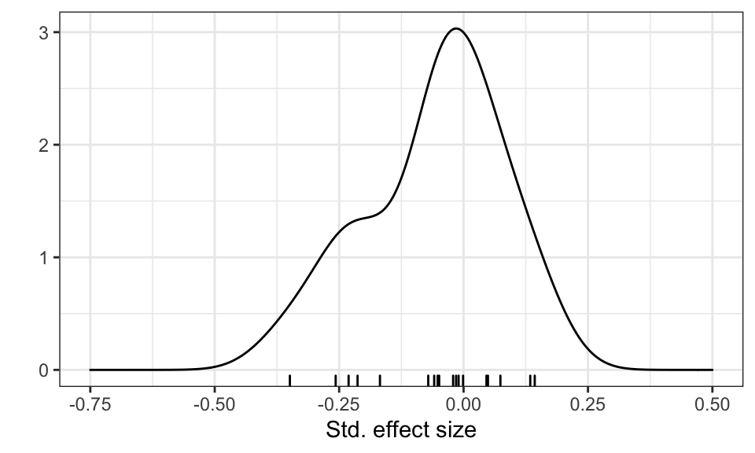

```r
##### Plot just SST covariate effect
ggplot(cov_effects
       ,aes(x=sst
              #value, color = covariate, fill = covariate
            ))+
  geom_density(alpha=0.5)+
  geom_rug()+
  scale_x_continuous(limits=c(-0.75,0.5))+
  scale_fill_viridis(discrete = T)+
  ylab("")+
  xlab("Std. effect size")+
  theme_bw()
```

These are just point estimates of effects from independent linear regressions, but they give a general sense of the correlations between covariates and sockeye survival. THe standardized effect size is the change in sockeye productivity (in log space) per standard deviation unit increase in the covariate.

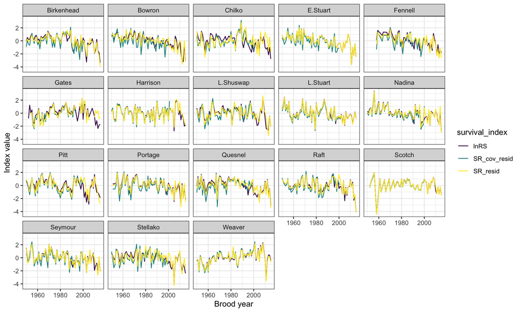

```r
## plot full survival index time series
ggplot(survial_indicesL, aes(brood_year, value,colour = survival_index)) +
  geom_line()+
  facet_wrap(~stock_name,nrow=4)+
  scale_colour_viridis_d()+
  xlab("Brood year")+
  ylab("Index value")+
  theme_bw()
```

Note that the survival indices have been standardized (mean = zero, std. dev. = one).

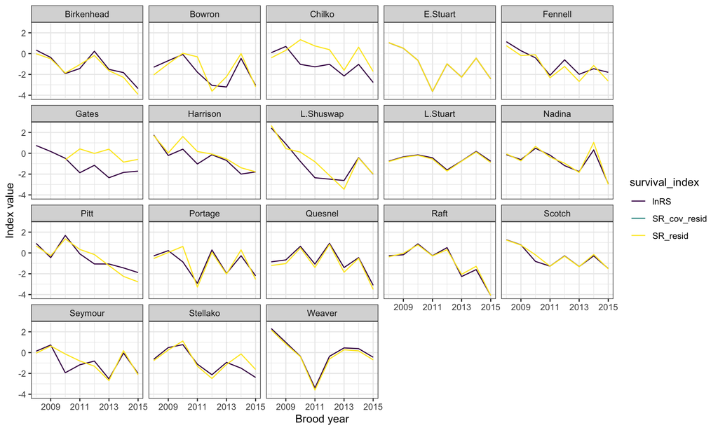

```r
## plot survival indices for recent years with SSHI pathogen data
ggplot(survial_indicesL[survial_indicesL$brood_year>2007,], aes(brood_year, value, colour = survival_index)) +
  geom_line()+
  facet_wrap(~stock_name,nrow=4)+
  scale_x_continuous(breaks = c(2009,2011,2013,2015))+
  scale_colour_viridis_d()+
  xlab("Brood year")+
  ylab("Index value")+
  theme_bw()
```

These index values are what can be related to prevalence/load profiles of out-migrating juveniles in stage 2 of the analyses. Looks like some reasonable contrast among years and stocks. My advice for stage 2 is to use the stock-recruit residuals without covariates as the base survival index, and do a sensitivity analysis with the other two.